# Silent_Stroke_Predictive_Models

Patricia Laurencia Woge

2023-05-09

# About Dataset

Data Description: https://www.kaggle.com/datasets/fedesoriano/stroke-prediction-dataset?resource=download

### Context

This dataset is used to predict whether a patient is likely to get stroke based on the input parameters like gender, age, various diseases, and smoking status. Each row in the data provides relavant information about the patient.

### Attribute Information

1. id: unique identifier
2. gender: “Male”, “Female” or “Other”
3. age: age of the patient
4. hypertension: 0 if the patient doesn’t have hypertension, 1 if the patient has hypertension
5. heart_disease: 0 if the patient doesn’t have any heart diseases, 1 if the patient has a heart disease
6. ever_married: “No” or “Yes”
7. work_type: “children”, “Govt_jov”, “Never_worked”, “Private” or “Self-employed”
8. Residence_type: “Rural” or “Urban”
9. avg_glucose_level: average glucose level in blood
10. bmi: body mass index
11. smoking_status: “formerly smoked”, “never smoked”, “smokes” or “Unknown”*
12. stroke: 1 if the patient had a stroke or 0 if not *Note: “Unknown” in smoking_status means that the information is unavailable for this patient

Background: According to the World Health Organization (WHO) stroke is the 2nd leading cause of death globally, responsible for approximately 11% of total deaths,incidence of stroke is increasing with age, mainly due to lifestyle changes. Many people may think that a stroke must show symptoms. Whereas there are also strokes that do not have obvious symptoms or commonly called silent strokes. This condition is even more common. Silent stroke is a type of stroke that usually does not show common symptoms. In many cases, sufferers do not even know they have the disease. Therefore, our group wanted to identify these factors such as age, gender, environment, status, lifestyle and medical history by creating a prediction model.

Objective: This analysis can help people predict silent stroke, which is a stroke that does not cause obvious symptoms, which can be influenced by various factors and can occur in individuals of any age, gender, environment, status, lifestyle and medical history.

# Load library

```r
library(corrplot)
library(dplyr)
library(scales)
library(ggplot2)
library(gridExtra)
library(scorecard)
library(egg)
library(ggpubr)
library(DescTools)
library(rcompanion)
library(forcats)
library(randomForest)
library(rpart.plot)
library(rpart)
library(pROC)
library(MLmetrics)
library(Hmisc)
```

# Load Dataset

```r
PATH <- "C:/Users/ASUS/Downloads/healthcare-dataset-stroke-data.csv"
df <- read.csv(PATH)
```

# Understand the Data

### Copy the data so any changes doesn’t directly impact the original dataset

```r
cleaned_data = df
```

### Dimension of the data

```r
dim(cleaned_data)
```

```
## [1] 5110   12
```

This dataset consists of 5110 observations and 12 columns

### View content of data

```r
head(cleaned_data)
```

```
##      id gender age hypertension heart_disease ever_married     work_type
## 1  9046   Male  67            0             1          Yes       Private
## 2 51676 Female  61            0             0          Yes Self-employed
## 3 31112   Male  80            0             1          Yes       Private
## 4 60182 Female  49            0             0          Yes       Private
## 5  1665 Female  79            1             0          Yes Self-employed
## 6 56669   Male  81            0             0          Yes       Private
##   Residence_type avg_glucose_level  bmi  smoking_status stroke
## 1          Urban            228.69 36.6 formerly smoked      1
## 2          Rural            202.21  N/A    never smoked      1
## 3          Rural            105.92 32.5    never smoked      1
## 4          Urban            171.23 34.4          smokes      1
## 5          Rural            174.12   24    never smoked      1
## 6          Urban            186.21   29 formerly smoked      1
```

### View the structure of data

```r
str(cleaned_data)
```

```
## 'data.frame':    5110 obs. of  12 variables:
##  $ id               : int  9046 51676 31112 60182 1665 56669 53882 10434 27419 60491 ...
##  $ gender           : chr  "Male" "Female" "Male" "Female" ...
##  $ age              : num  67 61 80 49 79 81 74 69 59 78 ...
##  $ hypertension     : int  0 0 0 0 1 0 1 0 0 0 ...
##  $ heart_disease    : int  1 0 1 0 0 0 1 0 0 0 ...
##  $ ever_married     : chr  "Yes" "Yes" "Yes" "Yes" ...
##  $ work_type        : chr  "Private" "Self-employed" "Private" "Private" ...
##  $ Residence_type   : chr  "Urban" "Rural" "Rural" "Urban" ...
##  $ avg_glucose_level: num  229 202 106 171 174 ...
##  $ bmi              : chr  "36.6" "N/A" "32.5" "34.4" ...
##  $ smoking_status   : chr  "formerly smoked" "never smoked" "never smoked" "smokes" ...
##  $ stroke           : int  1 1 1 1 1 1 1 1 1 1 ...
```

In this data there are three different data types for each variable, namely integer, numeric and character.

• Variables with integer data types include id, hypertension, heart_disease and stroke. • Variables with numeric data types include age and avg_glucose_level. • Variables with character data type include gender, ever_married, work_type, residence_type, bmi, and smoking_status.

However, As we can see that some variables have incompatible data types, therefore after we understand the whole data, we first clean this data before doing further data exploration and data modeling. We do this to avoid repeating the work of exploring and visualizing the data.

### Check the variable names

```r
names(cleaned_data)
```

```
##  [1] "id"                "gender"            "age"
##  [4] "hypertension"      "heart_disease"     "ever_married"
##  [7] "work_type"         "Residence_type"    "avg_glucose_level"
## [10] "bmi"               "smoking_status"    "stroke"
```

This dataset has meaningful variable names that can be easily understoo

### Check missing Values

```r
sapply(cleaned_data, function(x) sum(is.na(x)))
```

```
##                id            gender               age      hypertension
##                 0                 0                 0                 0
##     heart_disease      ever_married         work_type    Residence_type
##                 0                 0                 0                 0
## avg_glucose_level               bmi    smoking_status            stroke
##                 0                 0                 0                 0
```

In this data there are no missing values at all, this may be due to inappropriate data types in some variables which cause missing values not to be detected in all observations.

### Check duplicate rows

```r
duplicate_rows <- duplicated(cleaned_data)

num_duplicates <- sum(duplicate_rows)

if (num_duplicates > 0) {
  cat("The dataset has", num_duplicates, "duplicate row(s).\n")
} else {
  cat("The dataset does not have any duplicate rows.\n")
}
```

```
## The dataset does not have any duplicate rows.
```

```r
BasicSummary <- function(df, dgts = 3){
  m <- ncol(df)
  varNames <- colnames(df)
  varType <- vector("character",m)
  topLevel <- vector("character",m)
  topCount <- vector("numeric",m)
  missCount <- vector("numeric",m)
  levels <- vector("numeric", m)
  for (i in 1:m){
    x <- df[,i]
      varType[i] <- class(x)
      xtab <- table(x, useNA = "ifany")
      levels[i] <- length(xtab)
      nums <- as.numeric(xtab)
      maxnum <- max(nums)
      topCount[i] <- maxnum
      maxIndex <- which.max(nums)
      lvls <- names(xtab)
      topLevel[i] <- lvls[maxIndex]
      missIndex <- which((is.na(x)) | (x == "") | (x == " "))
      missCount[i] <- length(missIndex)
  }
  n <- nrow(df)
  topFrac <- round(topCount/n, digits = dgts)
  missFrac <- round(missCount/n, digits = dgts)
  summaryFrame <- data.frame(variable = varNames, type = varType,
  levels = levels, topLevel = topLevel,
  topCount = topCount, topFrac = topFrac,
  missFreq = missCount, missFrac = missFrac)
  return(summaryFrame)
}

BasicSummary(cleaned_data)
```

```
##             variable      type levels     topLevel topCount topFrac missFreq
## 1                 id   integer   5110           67        1   0.000        0
## 2             gender character      3       Female     2994   0.586        0
## 3                age   numeric    104           78      102   0.020        0
## 4       hypertension   integer      2            0     4612   0.903        0
## 5      heart_disease   integer      2            0     4834   0.946        0
## 6       ever_married character      2          Yes     3353   0.656        0
## 7          work_type character      5      Private     2925   0.572        0
## 8     Residence_type character      2        Urban     2596   0.508        0
## 9  avg_glucose_level   numeric   3979        93.88        6   0.001        0
## 10               bmi character    419          N/A      201   0.039        0
## 11    smoking_status character      4 never smoked     1892   0.370        0
## 12            stroke   integer      2            0     4861   0.951        0
##    missFrac
## 1         0
## 2         0
## 3         0
## 4         0
## 5         0
## 6         0
## 7         0
## 8         0
## 9         0
## 10        0
## 11        0
## 12        0
```

#### Conclusion

```r
Hmisc::describe(cleaned_data)
```

```
## cleaned_data
##
##  12  Variables      5110  Observations
## --------------------------------------------------------------------------------
## id
##        n  missing distinct     Info     Mean      Gmd      .05      .10
##     5110        0     5110        1    36518    24436     3590     6972
##      .25      .50      .75      .90      .95
##    17741    36932    54682    65668    69218
##
## lowest :    67    77    84    91    99, highest: 72911 72914 72915 72918 72940
## --------------------------------------------------------------------------------
## gender
##        n  missing distinct
##     5110        0        3
##
## Value      Female   Male  Other
## Frequency    2994   2115      1
## Proportion  0.586  0.414  0.000
## --------------------------------------------------------------------------------
## age
##        n  missing distinct     Info     Mean      Gmd      .05      .10
##     5110        0      104        1    43.23    26.03        5       11
##      .25      .50      .75      .90      .95
##       25       45       61       75       79
##
## lowest : 0.08 0.16 0.24 0.32 0.4 , highest: 78   79   80   81   82
## --------------------------------------------------------------------------------
## hypertension
##        n  missing distinct     Info      Sum     Mean      Gmd
##     5110        0        2    0.264      498  0.09746    0.176
##
## --------------------------------------------------------------------------------
## heart_disease
##        n  missing distinct     Info      Sum     Mean      Gmd
##     5110        0        2    0.153      276  0.05401   0.1022
##
## --------------------------------------------------------------------------------
## ever_married
##        n  missing distinct
```

[output cut: 38 more lines]

```
## lowest : 10.3 11.3 11.5 12   12.3, highest: 71.9 78   92   97.6 N/A
## --------------------------------------------------------------------------------
## smoking_status
##        n  missing distinct
##     5110        0        4
##
## Value      formerly smoked    never smoked          smokes         Unknown
## Frequency              885            1892             789            1544
## Proportion           0.173           0.370           0.154           0.302
## --------------------------------------------------------------------------------
## stroke
##        n  missing distinct     Info      Sum     Mean      Gmd
##     5110        0        2    0.139      249  0.04873  0.09273
##
## --------------------------------------------------------------------------------
```

#### Conclusion:

Before we proceed with further exploratory data analysis and visualization, we do this to avoid duplicating the effort of exploring and visualizing the data.

# Data Cleaning

### Keep used variables

After we understand te data, we can discard variables/features that are not needed for the next process.

```r
keepVars <- c("gender",'age','hypertension','heart_disease','ever_married','work_type','Residence_type','avg_glucose_level','bmi', 'smoking_status','stroke')
cleaned_data <- cleaned_data[, keepVars]
```

```r
head(cleaned_data)
```

```
##   gender age hypertension heart_disease ever_married     work_type
## 1   Male  67            0             1          Yes       Private
## 2 Female  61            0             0          Yes Self-employed
## 3   Male  80            0             1          Yes       Private
## 4 Female  49            0             0          Yes       Private
## 5 Female  79            1             0          Yes Self-employed
## 6   Male  81            0             0          Yes       Private
##   Residence_type avg_glucose_level  bmi  smoking_status stroke
## 1          Urban            228.69 36.6 formerly smoked      1
## 2          Rural            202.21  N/A    never smoked      1
## 3          Rural            105.92 32.5    never smoked      1
## 4          Urban            171.23 34.4          smokes      1
## 5          Rural            174.12   24    never smoked      1
## 6          Urban            186.21   29 formerly smoked      1
```

As we can see, now the id column has been removed from the dataframe

### Change data type into appropriate data type

#### As before, we can see that the variables have incompatible data types, so we have to change them to the appropriate data types.

#### For variables with character and integer data types, they will be converted into factor data types, except for bmi, which will be converted into numeric data types.

```r
cleaned_data$gender<-as.factor(cleaned_data$gender)
cleaned_data$hypertension<-as.factor(cleaned_data$hypertension)
cleaned_data$heart_disease<-as.factor(cleaned_data$heart_disease)
cleaned_data$ever_married<-as.factor(cleaned_data$ever_married)
cleaned_data$work_type<-as.factor(cleaned_data$work_type)
cleaned_data$Residence_type<-as.factor(cleaned_data$Residence_type)
cleaned_data$smoking_status<-as.factor(cleaned_data$smoking_status)
cleaned_data$stroke<-as.factor(cleaned_data$stroke)
cleaned_data$bmi<-as.numeric(cleaned_data$bmi)
str(cleaned_data)
```

```
## 'data.frame':    5110 obs. of  11 variables:
##  $ gender           : Factor w/ 3 levels "Female","Male",..: 2 1 2 1 1 2 2 1 1 1 ...
##  $ age              : num  67 61 80 49 79 81 74 69 59 78 ...
##  $ hypertension     : Factor w/ 2 levels "0","1": 1 1 1 1 2 1 2 1 1 1 ...
##  $ heart_disease    : Factor w/ 2 levels "0","1": 2 1 2 1 1 1 2 1 1 1 ...
##  $ ever_married     : Factor w/ 2 levels "No","Yes": 2 2 2 2 2 2 2 1 2 2 ...
##  $ work_type        : Factor w/ 5 levels "children","Govt_job",..: 4 5 4 4 5 4 4 4 4 4 ...
##  $ Residence_type   : Factor w/ 2 levels "Rural","Urban": 2 1 1 2 1 2 1 2 1 2 ...
##  $ avg_glucose_level: num  229 202 106 171 174 ...
##  $ bmi              : num  36.6 NA 32.5 34.4 24 29 27.4 22.8 NA 24.2 ...
##  $ smoking_status   : Factor w/ 4 levels "formerly smoked",..: 1 2 2 3 2 1 2 2 4 4 ...
##  $ stroke           : Factor w/ 2 levels "0","1": 2 2 2 2 2 2 2 2 2 2 ...
```

Now the data types for each variable has been changed into appropriate data types

### Check missing value

```r
sapply(cleaned_data, function(x) sum(is.na(x)))
```

```
##            gender               age      hypertension     heart_disease
##                 0                 0                 0                 0
##      ever_married         work_type    Residence_type avg_glucose_level
##                 0                 0                 0                 0
##               bmi    smoking_status            stroke
##               201                 0                 0
```

### Replace Missing value of BMI

### Next, check the distribution of BMI to know what central tendency best to fill NA

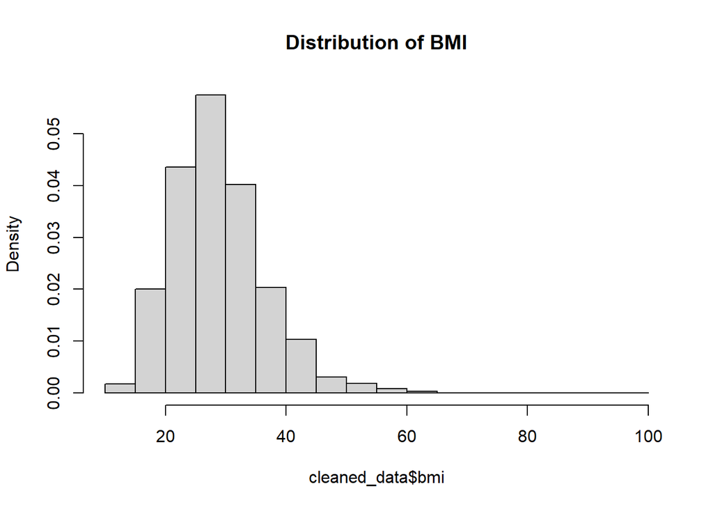

```r
hist(cleaned_data$bmi, freq = FALSE, main = "Distribution of BMI")
```

As seen, it’s right skewed. In a skewed distribution, the mean is often a preferred measure of central tendency, as the median is not usually in the middle of the distribution

### Fill the NA BMI values with mean

```r
cleaned_data$bmi[is.na(cleaned_data$bmi)]<-mean(cleaned_data$bmi,na.rm=TRUE)
```

### Check the missing value

```r
sum(is.na(cleaned_data$bmi))
```

```
## [1] 0
```

now, there’s no missing values in BMI

### Replace the ‘Unknown’ status

#### Change the ‘Unknown’ in smoking_status into N/A

```r
smoking_stat <- which(cleaned_data$smoking_status == "Unknown")
cleaned_data$smoking_status[smoking_stat] <- NA
sum(is.na(cleaned_data$smoking_status))
```

```
## [1] 1544
```

We can observe that in the “smoking_status” variable, the “Unknown” category accounts for a significant proportion of the data, specifically 1544 out of 5110 observations, or approximately 30% of the data. Therefore, considering the imbalanced nature of the target variable, stroke, we are considering not removing the “Unknown” category. Our consideration is to transform the “Unknown” status in the smoking_status variable into “never smoke” because “never smoke” is the most frequent category or can be considered the mode of the smoking_status variable.

```r
cleaned_data$smoking_status[is.na(cleaned_data$smoking_status)] <- "never smoked"
```

```r
sum(is.na(cleaned_data$smoking_status))
```

```
## [1] 0
```

Now, we can see that ‘Unknown’ in smoking_status has been changed into ‘never smoked’

### Removing ‘Other’ from gender variable

```r
cleaned_data = cleaned_data %>% filter(gender != "Other")
```

Filter for whom gender is Other is excluded (it’s only 1 data)

```r
sapply(cleaned_data, function(x) length(unique(x)))
```

```
##            gender               age      hypertension     heart_disease
##                 2               104                 2                 2
##      ever_married         work_type    Residence_type avg_glucose_level
##                 2                 5                 2              3978
##               bmi    smoking_status            stroke
##               419                 3                 2
```

After removing ‘other’ from gender variable, now it’s only have two levels for gender

### Check the data after cleaning

```r
Hmisc::describe(cleaned_data)
```

```
## cleaned_data
##
##  11  Variables      5109  Observations
## --------------------------------------------------------------------------------
## gender
##        n  missing distinct
##     5109        0        2
##
## Value      Female   Male
## Frequency    2994   2115
## Proportion  0.586  0.414
## --------------------------------------------------------------------------------
## age
##        n  missing distinct     Info     Mean      Gmd      .05      .10
##     5109        0      104        1    43.23    26.03        5       11
##      .25      .50      .75      .90      .95
##       25       45       61       75       79
##
## lowest : 0.08 0.16 0.24 0.32 0.4 , highest: 78   79   80   81   82
## --------------------------------------------------------------------------------
## hypertension
##        n  missing distinct
##     5109        0        2
##
## Value          0     1
## Frequency   4611   498
## Proportion 0.903 0.097
## --------------------------------------------------------------------------------
## heart_disease
##        n  missing distinct
##     5109        0        2
##
## Value          0     1
## Frequency   4833   276
## Proportion 0.946 0.054
## --------------------------------------------------------------------------------
## ever_married
##        n  missing distinct
##     5109        0        2
##
```

[output cut: 41 more lines]

```
##        n  missing distinct
##     5109        0        3
##
## Value      formerly smoked    never smoked          smokes
## Frequency              884            3436             789
## Proportion           0.173           0.673           0.154
## --------------------------------------------------------------------------------
## stroke
##        n  missing distinct
##     5109        0        2
##
## Value          0     1
## Frequency   4860   249
## Proportion 0.951 0.049
## --------------------------------------------------------------------------------
```

#### Conculsion:

After the cleaning process, the data consists of 11 variables and 5109 observations. The ‘Other’ category in the gender variable has been removed. There are no missing values in the ‘bmi’ variable. The ‘Unknown’ status in the smoking_status variable has been changed to ‘never smoked’. Additionally, the data types have been appropriately adjusted for each variable. Now the data is clean and ready for exploratory data analysis.

# Exploratory Data Analysis

### Check the descriptive statistics

```r
summary(cleaned_data)
```

```
##     gender          age        hypertension heart_disease ever_married
##  Female:2994   Min.   : 0.08   0:4611       0:4833        No :1756
##  Male  :2115   1st Qu.:25.00   1: 498       1: 276        Yes:3353
##  Other :   0   Median :45.00
##                Mean   :43.23
##                3rd Qu.:61.00
##                Max.   :82.00
##          work_type    Residence_type avg_glucose_level      bmi
##  children     : 687   Rural:2513     Min.   : 55.12    Min.   :10.30
##  Govt_job     : 657   Urban:2596     1st Qu.: 77.24    1st Qu.:23.80
##  Never_worked :  22                  Median : 91.88    Median :28.40
##  Private      :2924                  Mean   :106.14    Mean   :28.89
##  Self-employed: 819                  3rd Qu.:114.09    3rd Qu.:32.80
##                                      Max.   :271.74    Max.   :97.60
##          smoking_status stroke
##  formerly smoked: 884   0:4860
##  never smoked   :3436   1: 249
##  smokes         : 789
##  Unknown        :   0
##
##
```

Here, the summary of descriptive statistics.

### Plot

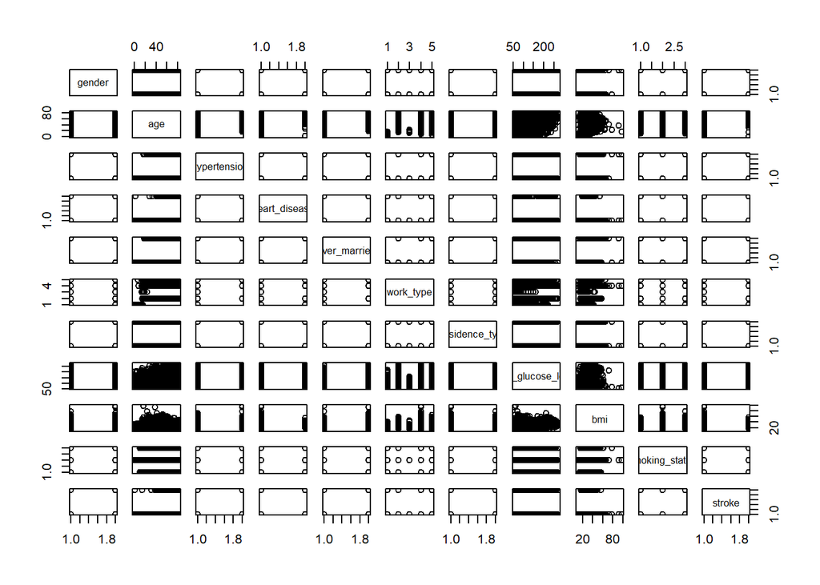

```r
plot(cleaned_data)
```

### Checking anomalies and normality on categorical variable

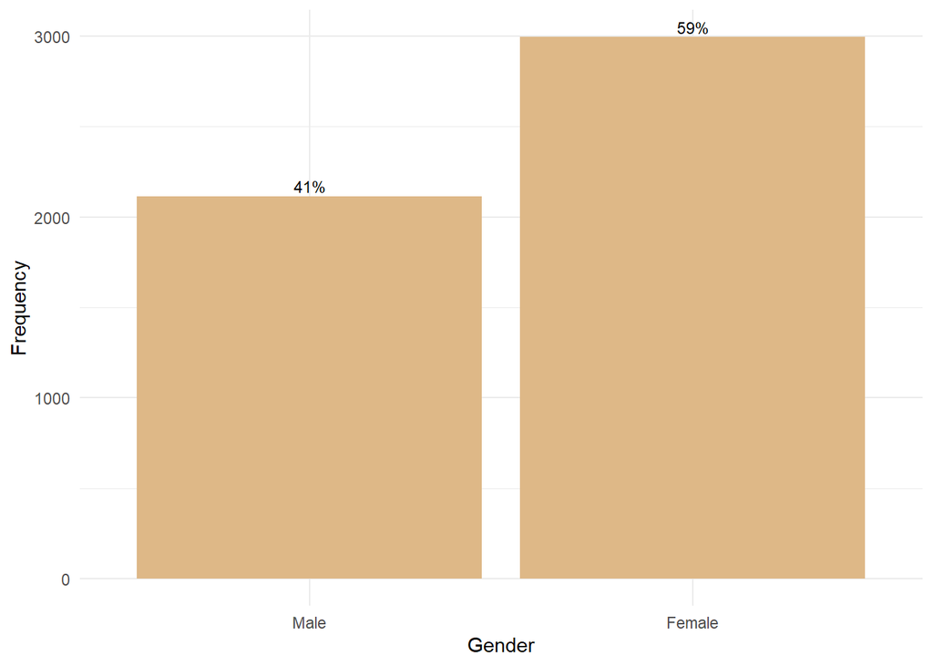

```r
genderBar <- cleaned_data %>%
  count(gender) %>%
  mutate(percentage = prop.table(n) * 100)

p1 <- ggplot(data = genderBar, aes(x = reorder(gender, n), y = n)) +
  geom_bar(stat = "identity", fill = "Burlywood") +
  geom_text(aes(label = paste0(round(percentage), "%")), vjust = -0.3, size = 3) +
  labs(x = "Gender", y = "Frequency") +
  theme_minimal()

p1
```

There are more females in this datasets.

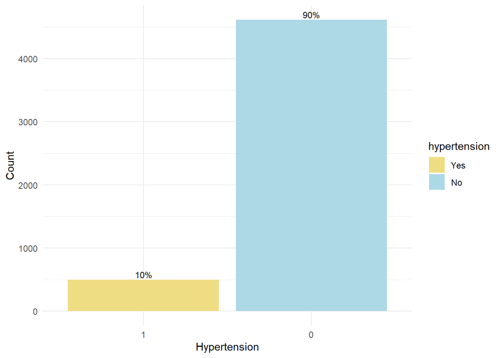

```r
hypertensionBar <- cleaned_data %>%
  count(hypertension = factor(hypertension, levels = c(1, 0)), name = "Count") %>%
  mutate(Percentage = prop.table(Count) * 100)

p2 <- ggplot(data = hypertensionBar, aes(x = hypertension, y = Count, fill = hypertension)) +
  geom_bar(stat = "identity") +
  geom_text(aes(label = paste0(round(Percentage), "%")), vjust = -0.3, size = 3) +
  scale_fill_manual(values = c("lightgoldenrod", "lightblue"), labels = c("Yes", "No")) +
  labs(x = "Hypertension", y = "Count") +
  theme_minimal()

# Show the plot
p2
```

Less people in this dataset have hypertension.

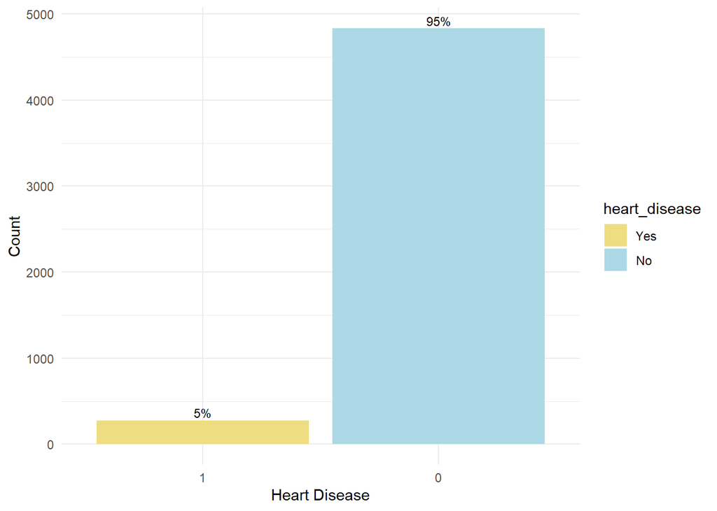

```r
heartDiseaseBar <- cleaned_data %>%
  count(heart_disease = factor(heart_disease, levels = c(1, 0)), name = "Count") %>%
  mutate(Percentage = prop.table(Count) * 100)

p3 <- ggplot(data = heartDiseaseBar, aes(x = heart_disease, y = Count, fill = heart_disease)) +
  geom_bar(stat = "identity") +
  geom_text(aes(label = paste0(round(Percentage), "%")), vjust = -0.3, size = 3) +
  scale_fill_manual(values = c("lightgoldenrod", "lightblue"), labels = c("Yes", "No")) +
  labs(x = "Heart Disease", y = "Count") +
  theme_minimal()

# Show the plot
p3
```

Less people in this dataset have heart disease.

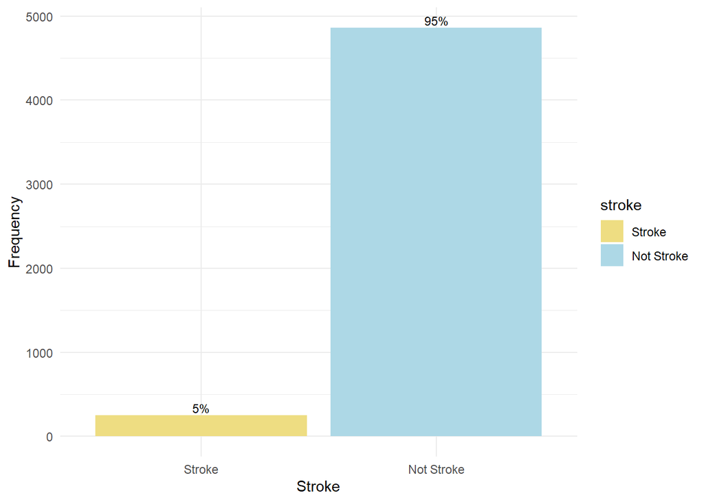

```r
strokeBar <- cleaned_data %>%
  mutate(stroke = factor(stroke, levels = c(1, 0), labels = c("Stroke", "Not Stroke"))) %>%
  count(stroke) %>%
  mutate(percentage = prop.table(n) * 100)

p4 <- ggplot(data = strokeBar, aes(x = stroke, y = n, fill = stroke)) +
  geom_bar(stat = "identity") +
  geom_text(aes(label = paste0(round(percentage), "%")), vjust = -0.3, size = 3) +
  scale_fill_manual(values = c("lightgoldenrod", "lightblue")) +
  labs(x = "Stroke", y = "Frequency") +
  theme_minimal()

# Show the plot
p4
```

Less people in this dataset have stroke. However, since the stroke variable is our target variable, it can be said that this dataset is not balanced because the proportion is very far.

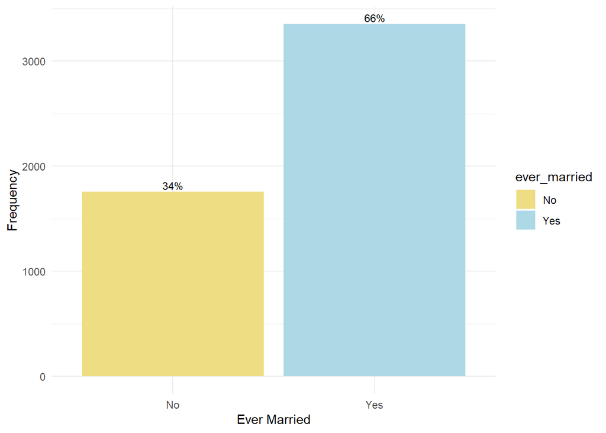

```r
mdata = df
married_Y <- which(mdata$ever_married == "Yes" )
mdata$ever_married[married_Y] <- 1
married_N <- which(mdata$ever_married == "No" )
mdata$ever_married[married_N] <- 0

mdata$ever_married <- as.integer(mdata$ever_married)

everMarriedBar <- mdata %>%
  count(ever_married) %>%
  mutate(Percentage = prop.table(n) * 100)

everMarriedBar$ever_married <- ifelse(everMarriedBar$ever_married == 1, "Yes", "No")

p5 <- ggplot(data = everMarriedBar, aes(x = reorder(ever_married, n), y = n, fill = ever_married)) +
  geom_bar(stat = "identity") +
  geom_text(aes(label = paste0(round(Percentage), "%")), vjust = -0.3, size = 3) +
  scale_fill_manual(values = c("lightgoldenrod", "lightblue")) +
  labs(x = "Ever Married", y = "Frequency") +
  theme_minimal()

# Show the plot
p5
```

More people in this dataset are married.

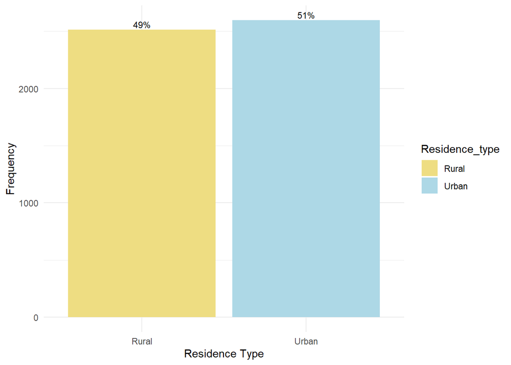

```r
residenceTypeBar <- cleaned_data %>%
  count(Residence_type) %>%
  mutate(Percentage = prop.table(n) * 100)

p6 <- ggplot(data = residenceTypeBar, aes(x = reorder(Residence_type, n), y = n, fill = Residence_type)) +
  geom_bar(stat = "identity") +
  geom_text(aes(label = paste0(round(Percentage), "%")), vjust = -0.3, size = 3) +
  scale_fill_manual(values = c("lightgoldenrod", "lightblue")) +
  labs(x = "Residence Type", y = "Frequency") +
  theme_minimal()

# Show the plot
p6
```

The residence places do not differ much.

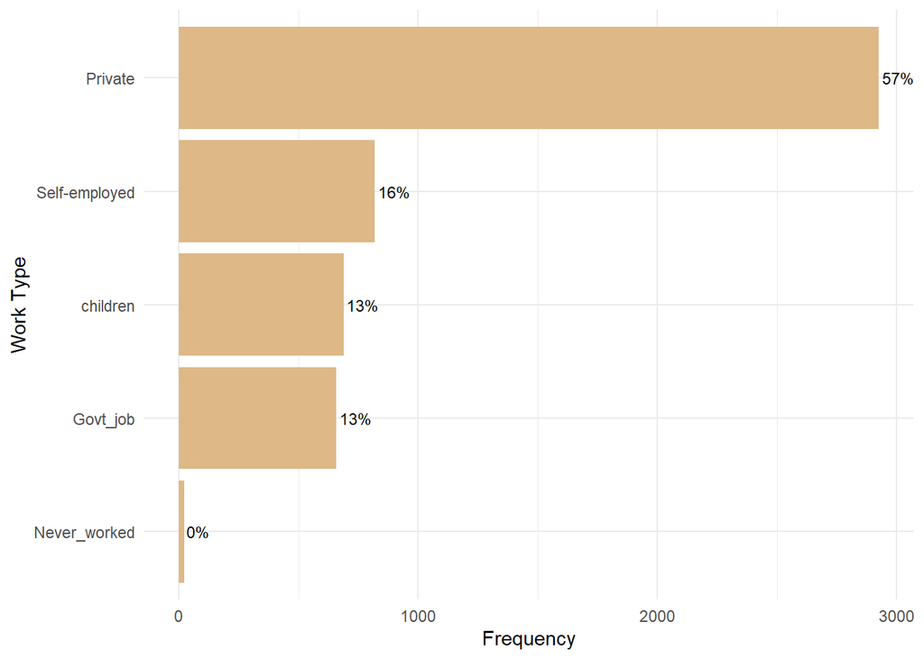

```r
workTypeBar <- cleaned_data %>%
  count(work_type) %>%
  mutate(Percentage = prop.table(n) * 100)

p7 <- ggplot(data = workTypeBar, aes(x = reorder(work_type, n), y = n, fill = work_type)) +
  geom_bar(stat = "identity", fill = "Burlywood") +
  geom_text(aes(label = paste0(round(Percentage), "%")), hjust = -0.1, size = 3) +
  labs(x = "Work Type", y = "Frequency") +
  theme_minimal() +
  coord_flip()

# Show the plot
p7
```

This dataset contains more people with jobs.

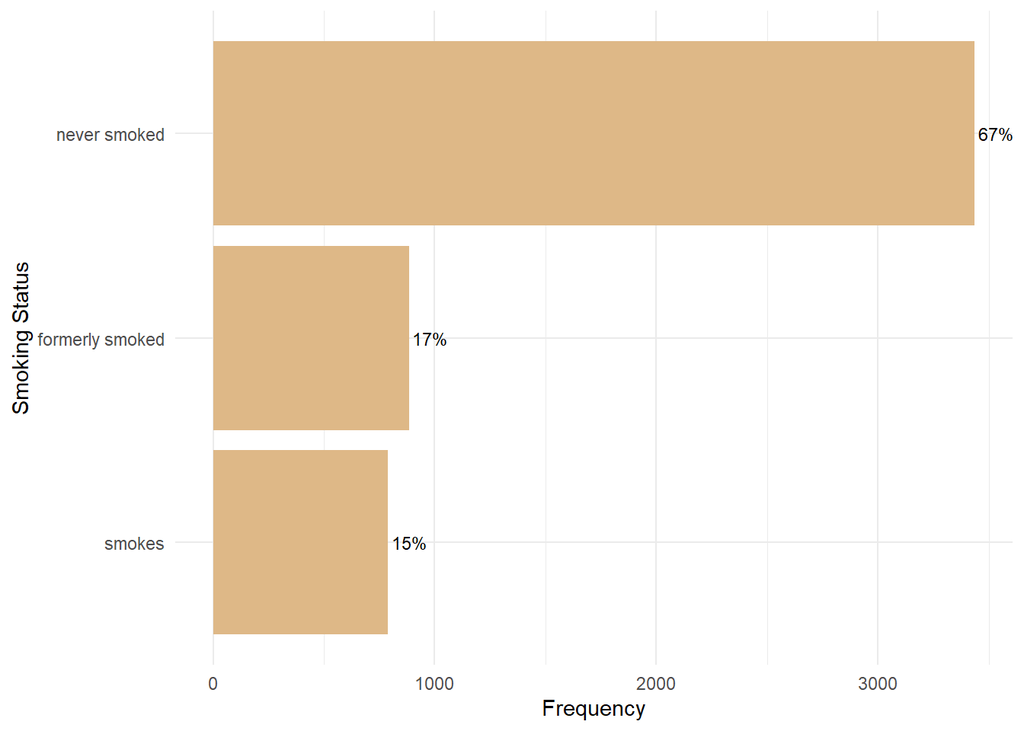

```r
smokingStatusTypeBar <- cleaned_data %>%
  count(smoking_status) %>%
  mutate(Percentage = prop.table(n) * 100)

p8 <- ggplot(data = smokingStatusTypeBar, aes(x = reorder(smoking_status, n), y = n, fill = smoking_status)) +
  geom_bar(stat = "identity", fill = "Burlywood") +
  geom_text(aes(label = paste0(round(Percentage), "%")), hjust = -0.1, size = 3) +
  labs(x = "Smoking Status", y = "Frequency") +
  theme_minimal() +
  coord_flip()

# Show the plot
p8
```

### Checking data anomalies for numeric variable

```r
FindOutliers <- function(x){
  # ThreeSigma
  t <- 3
  meanVar <- mean(x)
  sdVar <- sd(x)

  tsrLeft <- meanVar - t*sdVar
  tsrRight <- meanVar + t*sdVar


  outlier_tsrLeft = which(x < tsrLeft) # outlier kiri
  outlier_tsrRight = which(x > tsrRight) # outlier kanan

  sum_outlier_tsrLeft <- length(x[outlier_tsrLeft])
  sum_outlier_tsrRight <- length(x[outlier_tsrRight])
  total_sum_tsr <- sum_outlier_tsrLeft + sum_outlier_tsrRight

  #Hampel
  medianVar <- median(x) # batas kiri
  madVar <- mad(x) # batas kanan

  hampelLeft <- medianVar - t*madVar
  hampelRight <- medianVar + t*madVar

  outlier_hampelLeft = which(x < hampelLeft)
  outlier_hampelRight = which(x > hampelRight)

  sum_outlier_hampelLeft <- length(x[outlier_hampelLeft])
  sum_outlier_hampelRight <- length(x[outlier_hampelRight])

  total_sum_hampel <- sum_outlier_hampelLeft + sum_outlier_hampelRight


  #BoxPlot
  outliers_in_carat <- boxplot(x, plot = FALSE)$out

  sprintf("Three Sigma = %d, Hampel = %d, Box Plot = %d", total_sum_tsr,  total_sum_hampel, length(outliers_in_carat))
}
```

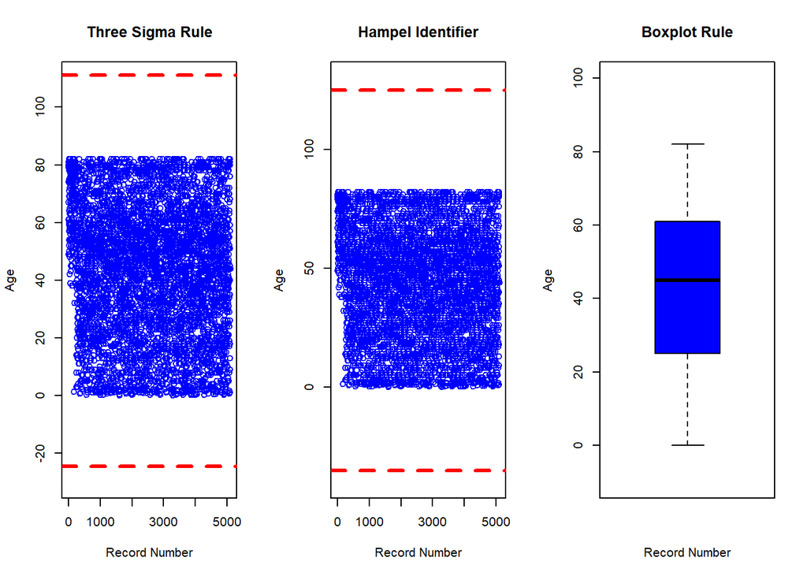

```r
x <- cleaned_data$age
par(mfrow=c(1,3), pty="m")
sd_var <- sd(x)
mean_var <- mean(x)
median_var <- median(x)
mad_var <- mad(x)

#Three Sigma Rule
plot(x, main='Three Sigma Rule', xlab='Record Number',ylab='Age', ylim=c(-30,110), col="blue")
abline(h=mean_var+3*(sd_var),col='red',lwd=3, lty = 2)
abline(h=mean_var-3*(sd_var),col='red',lwd=3, lty = 2)

#Hampel Identifier
plot(x,xlab='Record Number',ylab='Age',main='Hampel Identifier',ylim=c(-40,130), col="blue")
abline(h=median_var+3*mad_var,lty= 2 ,col='red',lwd=3)
abline(h=median_var-3*mad_var,lty= 2 ,col='red',lwd=3)

#Boxplot Rule
boxplot(x,xlab='Record Number',ylab='Age',main='Boxplot Rule',ylim=c(-10,100), col='blue')
```

```r
fullSummary <- FindOutliers(cleaned_data$age)
fullSummary
```

```
## [1] "Three Sigma = 0, Hampel = 0, Box Plot = 0"
```

From the results and graphs above, it can be observed that there are no outliers in the age variable.

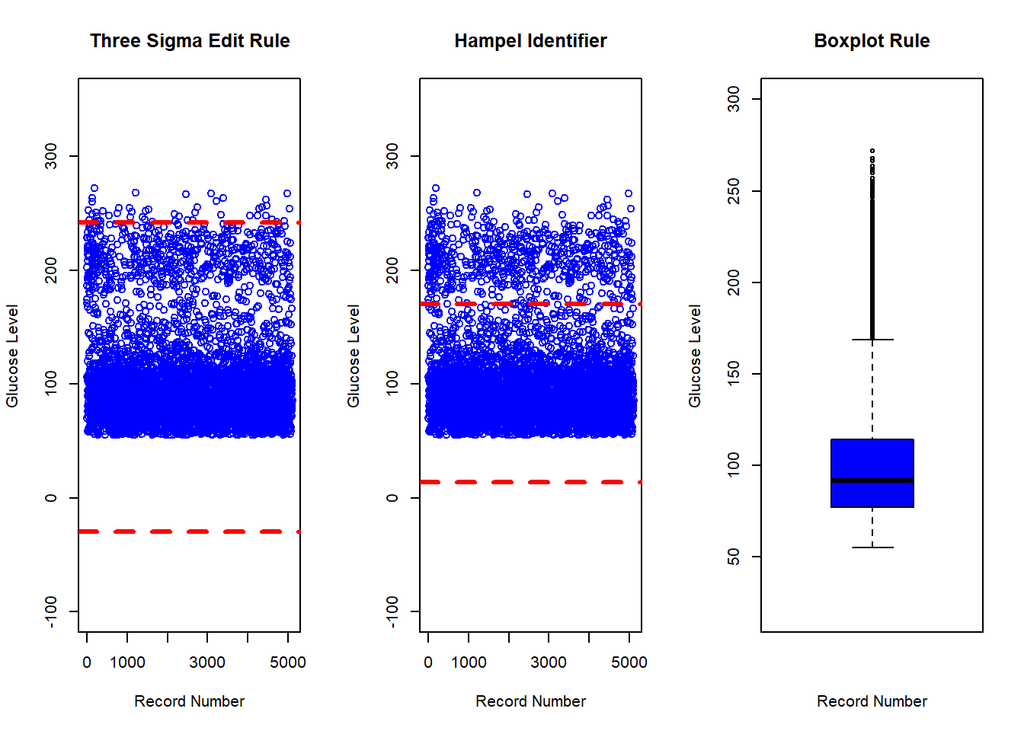

```r
x <- cleaned_data$avg_glucose_level
par(mfrow=c(1,3), pty="m")
sd_var <- sd(x)
mean_var <- mean(x)
median_var <- median(x)
mad_var <- mad(x)

#Three Sigma Edit Rule
plot(x, main='Three Sigma Edit Rule', xlab='Record Number',ylab='Glucose Level', ylim=c(-100,350), col="blue")
abline(h=mean_var+3*(sd_var),col='red',lwd=3, lty = 2)
abline(h=mean_var-3*(sd_var),col='red',lwd=3, lty = 2)

#Hampel Identifier
plot(x,xlab='Record Number',ylab='Glucose Level',main='Hampel Identifier',ylim=c(-100,350), col="blue")
abline(h=median_var+3*mad_var,lty= 2 ,col='red',lwd=3)
abline(h=median_var-3*mad_var,lty= 2 ,col='red',lwd=3)

#Boxplot Rule
boxplot(x,xlab='Record Number',ylab='Glucose Level',main='Boxplot Rule',ylim=c(20,300), col='blue')
```

```r
fullSummary <- FindOutliers(cleaned_data$avg_glucose_level)
fullSummary
```

```
## [1] "Three Sigma = 49, Hampel = 621, Box Plot = 627"
```

#### Conclusion

From the results and graphs above, it can be observed that the variable avg_glucose_level has a considerable number of outliers. Using the Three Sigma Rule, we identified 49 outliers, while the Hampel Rule identified 621 outliers, and the Boxplot Rule identified 627 outliers. However, despite the presence of outliers in this variable, we are considering not removing them from the dataset. Outliers in medical data often indicate abnormal conditions in individuals, and it is quite common for health-related data to exhibit such outliers.

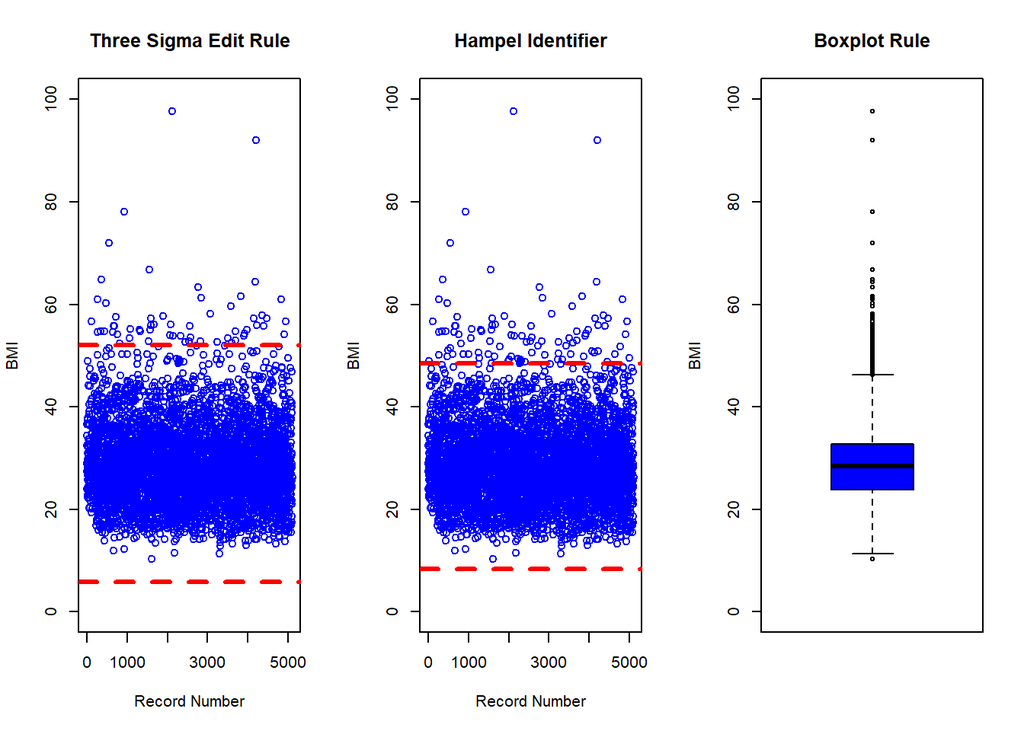

```r
x <- cleaned_data$bmi
par(mfrow=c(1,3), pty="m")
sd_var <- sd(x)
mean_var <- mean(x)
median_var <- median(x)
mad_var <- mad(x)

#Three Sigma Edit Rule
plot(x, main='Three Sigma Edit Rule', xlab='Record Number',ylab='BMI', ylim=c(0,100), col="blue")
abline(h=mean_var+3*(sd_var),col='red',lwd=3, lty = 2)
abline(h=mean_var-3*(sd_var),col='red',lwd=3, lty = 2)

#Hampel Identifier
plot(x,xlab='Record Number',ylab='BMI',main='Hampel Identifier',ylim=c(0,100), col="blue")
abline(h=median_var+3*mad_var,lty= 2 ,col='red',lwd=3)
abline(h=median_var-3*mad_var,lty= 2 ,col='red',lwd=3)

#Boxplot Rule
boxplot(x,ylab='BMI',main='Boxplot Rule',ylim=c(0,100), col='blue')
```

```r
fullSummary <- FindOutliers(cleaned_data$bmi)
fullSummary
```

```
## [1] "Three Sigma = 59, Hampel = 98, Box Plot = 126"
```

From the results and graphs above, it can be observed that the variable bmi has a considerable number of outliers. Using the Three Sigma Rule, we identified 59 outliers, while the Hampel Rule identified 98 outliers, and the Boxplot Rule identified 126 outliers. However, despite the presence of outliers in this variable, we are considering not removing them from the dataset. Outliers in medical data often indicate abnormal conditions in individuals, and it is quite common for health-related data to exhibit such outliers.

#### Conclusion

During anomaly checking, outliers were found in the variables avg_glucose_level and bmi. However, even though these variables contain outliers, we are considering not removing them because in medical data, the occurrence of outliers is quite normal for patient values.

### Checking data normality for numeric variable

```r
min_value <- min(cleaned_data$age)
max_value <- max(cleaned_data$age)

print(paste("Minimum value of age:", min_value))
```

```
## [1] "Minimum value of age: 0.08"
```

```r
print(paste("Maximum value of age:", max_value))
```

```
## [1] "Maximum value of age: 82"
```

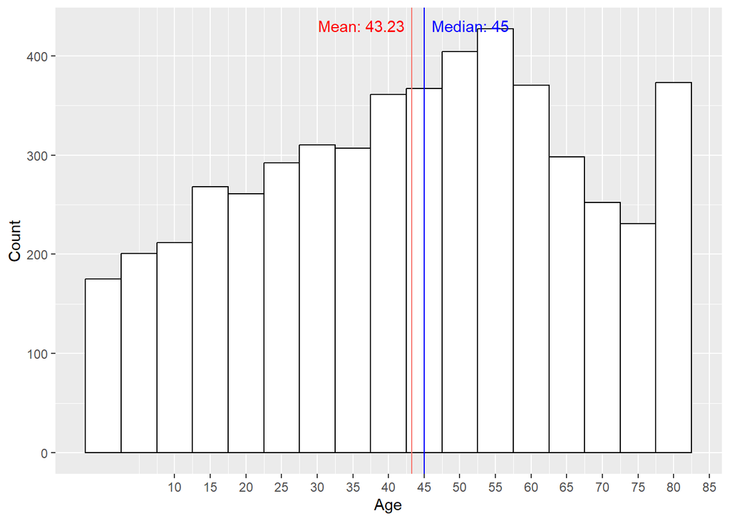

```r
gg = ggplot (cleaned_data)

mean_value <- mean(cleaned_data$age)
median_value <- median(cleaned_data$age)
p1 = gg + geom_histogram(aes(x = age), color = "black", fill = "white", binwidth = 5) +
  ylab('Count') +
  xlab('Age') +
  geom_vline(aes(xintercept = mean(age), color = "red")) +
  geom_vline(aes(xintercept = median(age)), color = "blue") +
  annotate("text", x = mean_value - 1, y = Inf, label = paste0("Mean: ", round(mean_value, 2)),
           vjust = 2, color = "red", hjust = 1) +
  annotate("text", x = median_value, y = Inf, label = paste0("Median: ", round(median_value, 2)),
           vjust = 2, color = "blue", hjust = -0.1) +
  scale_x_continuous(breaks = seq(10, 85, 5)) +
  theme(legend.position = "none")
p1
```

```r
min_value <- min(cleaned_data$avg_glucose_level)
max_value <- max(cleaned_data$avg_glucose_level)

print(paste("Minimum value of avg glucose level:", min_value))
```

```
## [1] "Minimum value of avg glucose level: 55.12"
```

```r
print(paste("Maximum value of avg glucose level:", max_value))
```

```
## [1] "Maximum value of avg glucose level: 271.74"
```

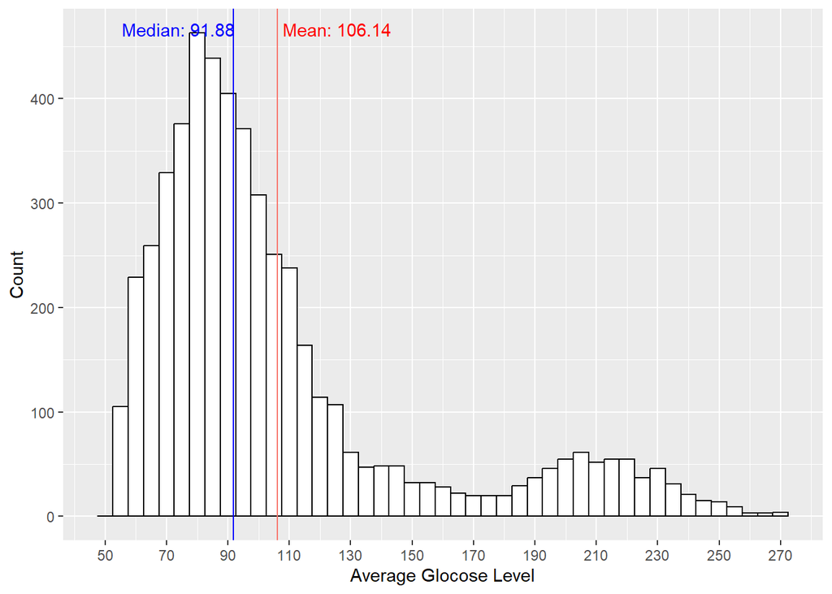

```r
mean_value <- mean(cleaned_data$avg_glucose_level)
median_value <- median(cleaned_data$avg_glucose_level)

p2 = gg + geom_histogram(aes(x = avg_glucose_level), color = "black", fill = "white", binwidth = 5) +
  ylab('Count') +
  xlab('Average Glocose Level') +
  geom_vline(aes(xintercept = mean(avg_glucose_level), color = "red")) +
  geom_vline(aes(xintercept = median(avg_glucose_level)), color = "blue") +
  annotate("text", x = mean_value + 37, y = Inf, label = paste0("Mean: ", round(mean_value, 2)),
           vjust = 2, color = "red", hjust = 1) +
  annotate("text", x = median_value - 40, y = Inf, label = paste0("Median: ", round(median_value, 2)),
           vjust = 2, color = "blue", hjust = -0.1) +
  scale_x_continuous(breaks = seq(50, 270, 20)) +
  theme(legend.position = "none")
p2
```

```r
min_value <- min(cleaned_data$bmi)
max_value <- max(cleaned_data$bmi)

print(paste("Minimum value of BMI:", min_value))
```

```
## [1] "Minimum value of BMI: 10.3"
```

```r
print(paste("Maximum value of BMI:", max_value))
```

```
## [1] "Maximum value of BMI: 97.6"
```

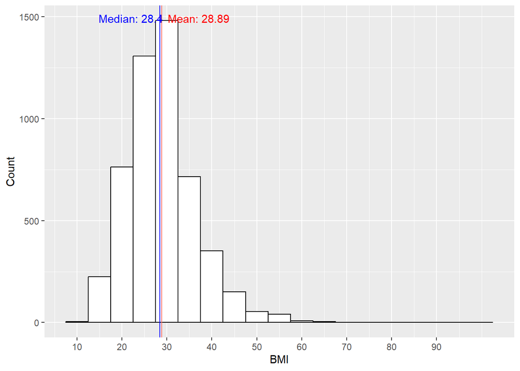

```r
mean_value <- mean(cleaned_data$bmi)
median_value <- median(cleaned_data$bmi)

p1 = gg + geom_histogram(aes(x = bmi), color = "black", fill = "white", binwidth = 5) +
  ylab('Count') +
  xlab('BMI') +
  geom_vline(aes(xintercept = mean(bmi), color = "red")) +
  geom_vline(aes(xintercept = median(bmi)), color = "blue") +
  annotate("text", x = mean_value + 15, y = Inf, label = paste0("Mean: ", round(mean_value, 2)),
           vjust = 2, color = "red", hjust = 1) +
  annotate("text", x = median_value - 15, y = Inf, label = paste0("Median: ", round(median_value, 2)),
           vjust = 2, color = "blue", hjust = -0.1) +
  scale_x_continuous(breaks = seq(10, 95, 10)) +
  theme(legend.position = "none")

p1
```

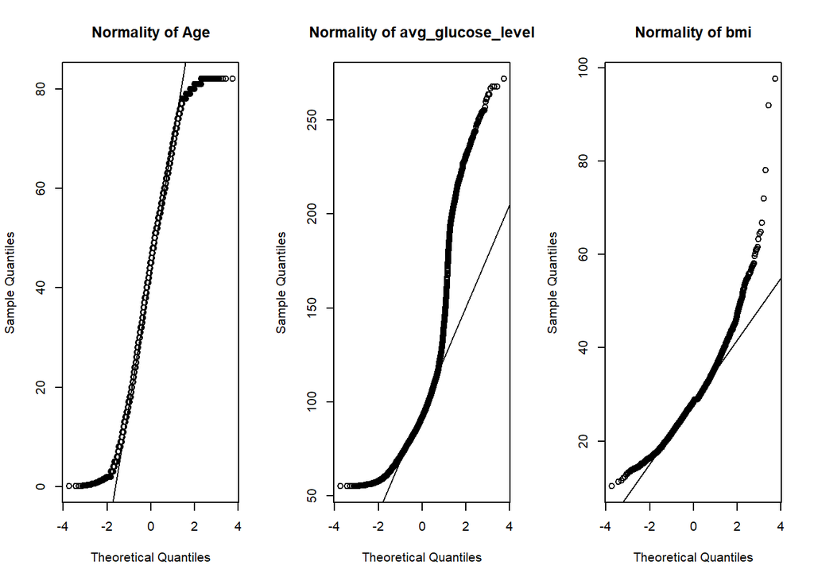

```r
par(mfrow = c(1,3))
qqnorm(cleaned_data$age,main="Normality of Age")
qqline(cleaned_data$age)
qqnorm(cleaned_data$avg_glucose_level,main="Normality of avg_glucose_level")
qqline(cleaned_data$avg_glucose_level)
qqnorm(cleaned_data$bmi,main="Normality of bmi")
qqline(cleaned_data$bmi)
```

## Bivariate Analysis

### Searching for the relationship between two variables

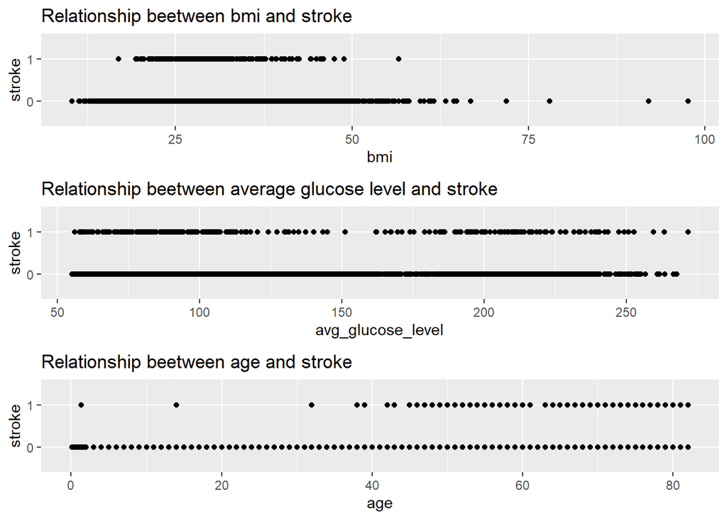

```r
pp1 = ggplot(cleaned_data, aes(bmi, stroke)) +
  geom_point() +
  labs(bmi = "BMI", stroke = "Stroke", title = "Relationship beetween bmi and stroke")

pp2 = ggplot(cleaned_data, aes(avg_glucose_level, stroke)) +
  geom_point() +
  labs(avg_glucose_level = "Average Glucose Level", stroke = "Stroke", title = "Relationship beetween average glucose level and stroke")

pp3 = ggplot(cleaned_data, aes(age, stroke)) +
  geom_point() +
  labs(age = "Age", stroke = "Stroke", title = "Relationship beetween age and stroke")

grid.arrange(pp1,pp2,pp3, ncol = 1)
```

1. Higher age, may likely to suffer from stroke.
2. Higher glucose_level the higher people can get in a stroke!
3. Most people’s BMI levels are around 20 to 30 and higher does not mean they are more likely to have a stroke. But it can be seen that higher bmi may easier to suffer from strokes.

```r
gender_data <- cleaned_data %>%
  group_by(gender, stroke) %>%
  summarise(count = sum(!is.na(stroke)))
```

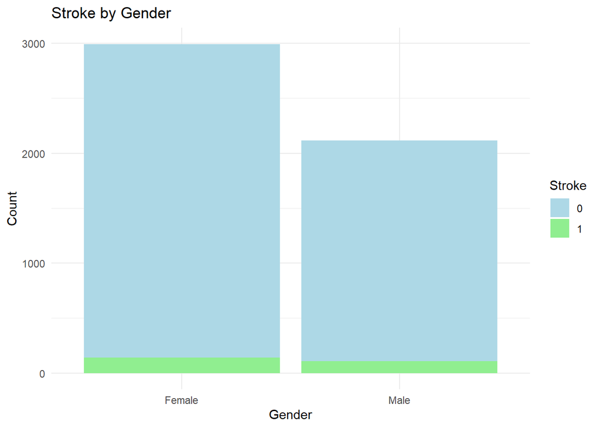

```r
pp1 <- ggplot(gender_data, aes(x = gender, y = count, fill = factor(stroke))) +
  geom_bar(stat = "identity") +
  scale_fill_manual(values = c("lightblue", "lightgreen")) +
  labs(x = "Gender", y = "Count", fill = "Stroke") +
  ggtitle("Stroke by Gender") +
  theme_minimal()
pp1
```

There is not much difference between a man and a woman. But in proportion, males are more likely to develop in proportion.

```r
work_type_data <- cleaned_data %>%
  group_by(work_type, stroke) %>%
  summarise(count = sum(!is.na(stroke)))
```

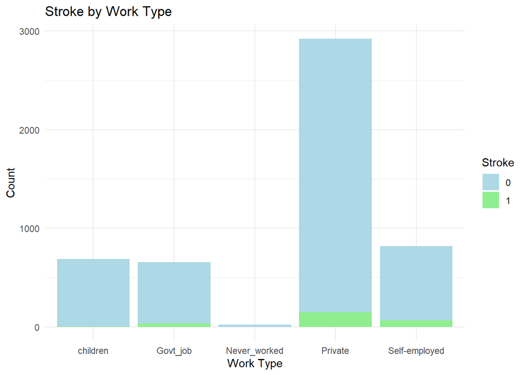

```r
pp2 <- ggplot(work_type_data, aes(x = work_type, y = count, fill = factor(stroke))) +
  geom_bar(stat = "identity") +
  scale_fill_manual(values = c("lightblue", "lightgreen")) +
  labs(x = "Work Type", y = "Count", fill = "Stroke") +
  ggtitle("Stroke by Work Type") +
  theme_minimal()
pp2
```

Overall, people who work are more likely to get strokes.

```r
residence_type_data <- cleaned_data %>%
  group_by(Residence_type, stroke) %>%
  summarise(count = sum(!is.na(stroke)))
```

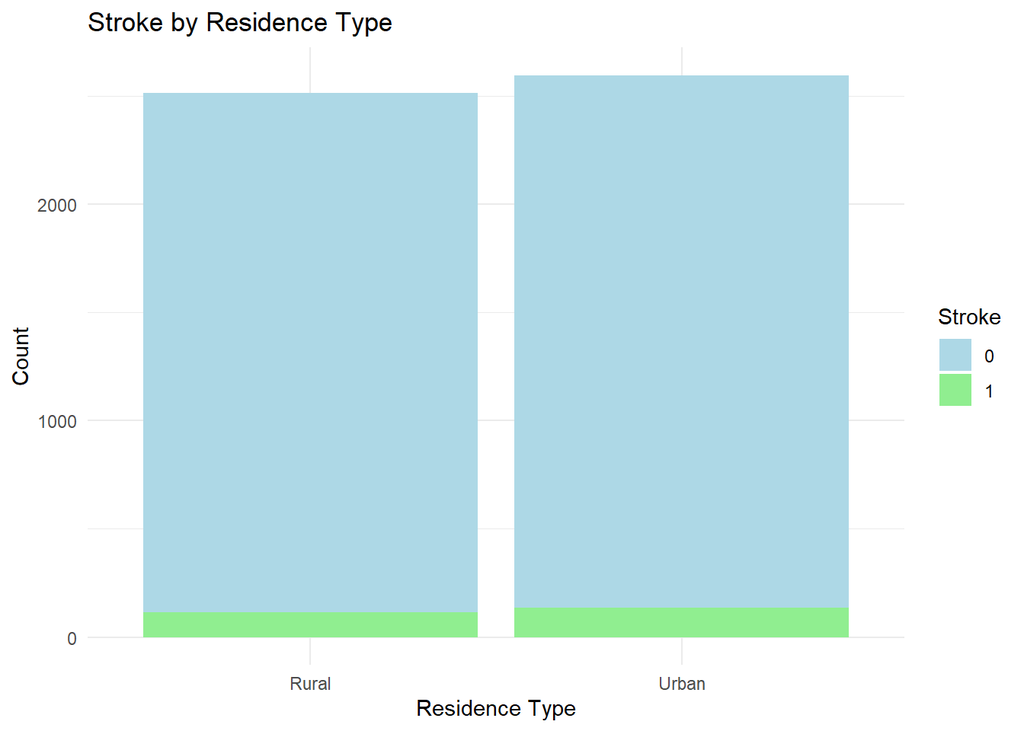

```r
pp3 <- ggplot(residence_type_data, aes(x = Residence_type, y = count, fill = factor(stroke))) +
  geom_bar(stat = "identity") +
  scale_fill_manual(values = c("lightblue", "lightgreen")) +
  labs(x = "Residence Type", y = "Count", fill = "Stroke") +
  ggtitle("Stroke by Residence Type") +
  theme_minimal()
pp3
```

For residence type, it seems not that useful feature.

```r
smoking_data <- cleaned_data %>%
  group_by(smoking_status, stroke) %>%
  summarise(count = sum(!is.na(stroke)))
```

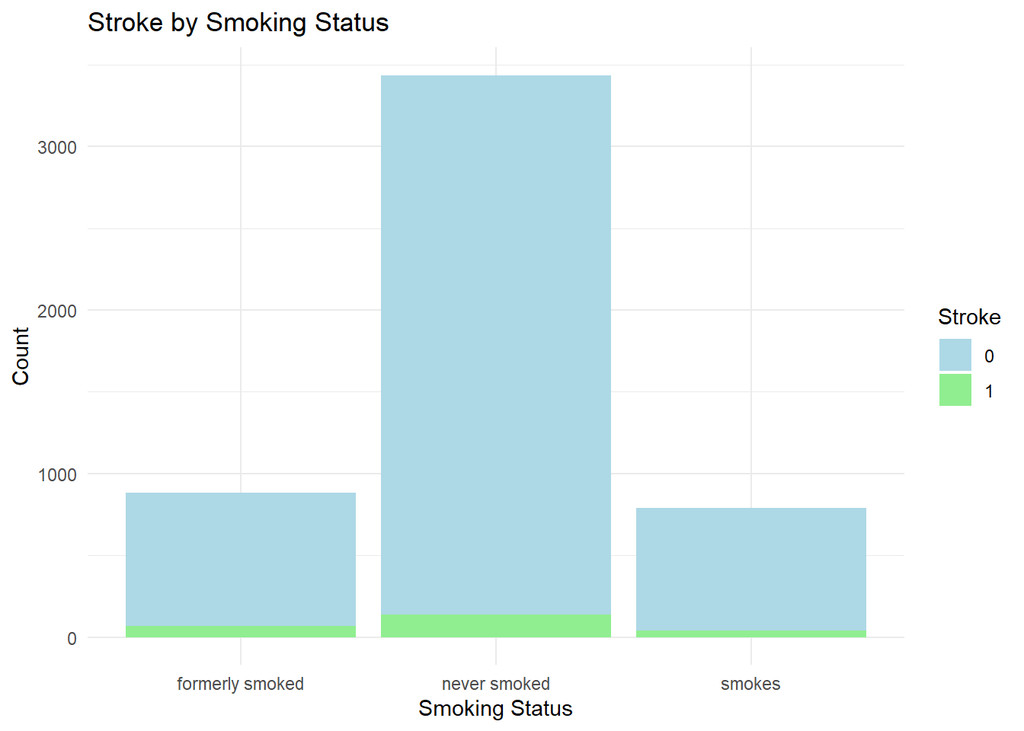

```r
pp4 <- ggplot(smoking_data, aes(x = smoking_status, y = count, fill = factor(stroke))) +
  geom_bar(stat = "identity") +
  scale_fill_manual(values = c("lightblue", "lightgreen")) +
  labs(x = "Smoking Status", y = "Count", fill = "Stroke") +
  ggtitle("Stroke by Smoking Status") +
  theme_minimal()
pp4
```

```r
cd = cleaned_data

cd <- cd %>%
  mutate(hypertension = ifelse(hypertension == 1, "Yes", "No"))

h_data <- cd %>%
  group_by(hypertension, stroke) %>%
  summarise(count = sum(!is.na(stroke)))
```

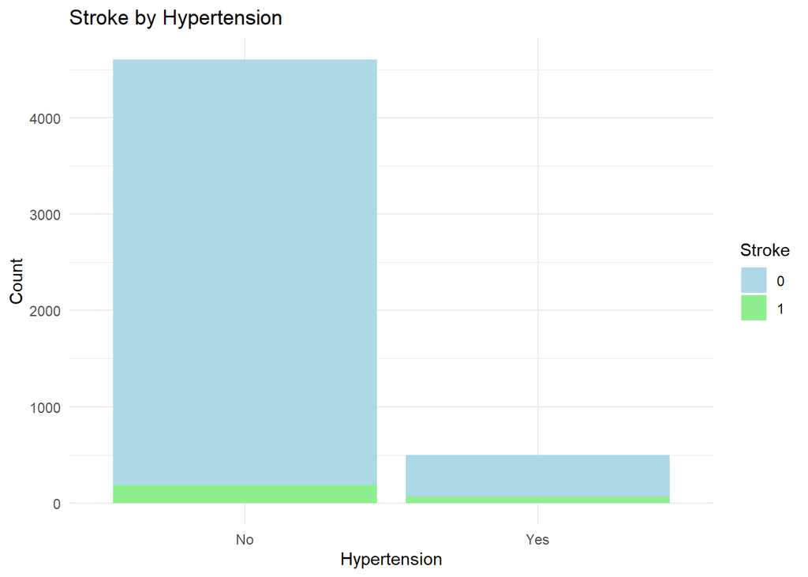

```r
pp5 <- ggplot(h_data, aes(x = hypertension, y = count, fill = factor(stroke))) +
  geom_bar(stat = "identity") +
  scale_fill_manual(values = c("lightblue", "lightgreen")) +
  labs(x = "Hypertension", y = "Count", fill = "Stroke") +
  ggtitle("Stroke by Hypertension") +
  theme_minimal()
pp5
```

For hypertension, there is not much difference between yes and no. In proportion, yes are more likely to develop in proportion.

```r
cd <- cd %>%
  mutate(heart_disease = ifelse(heart_disease == 1, "Yes", "No"))

h_data <- cd %>%
  group_by(heart_disease, stroke) %>%
  summarise(count = sum(!is.na(stroke)))
```

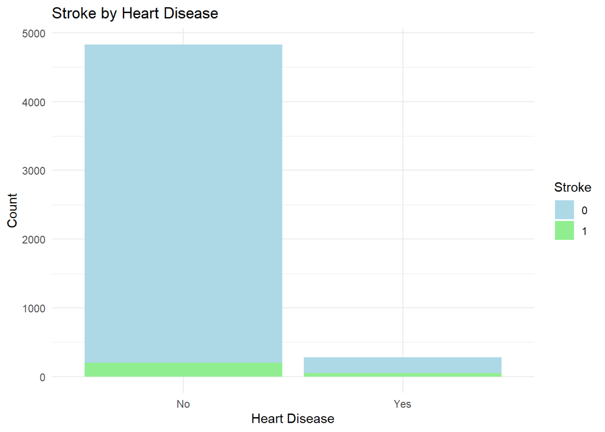

```r
pp6 <- ggplot(h_data, aes(x = heart_disease, y = count, fill = factor(stroke))) +
  geom_bar(stat = "identity") +
  scale_fill_manual(values = c("lightblue", "lightgreen")) +
  labs(x = "Heart Disease", y = "Count", fill = "Stroke") +
  ggtitle("Stroke by Heart Disease") +
  theme_minimal()
pp6
```

For heart_disease, there is not much difference between yes and no. But in proportion, yes are more likely to develop in proportion.

```r
m_data <- cd %>%
  mutate(ever_married_label = recode(ever_married, `1` = "Yes", `0` = "No")) %>%
  group_by(ever_married_label, stroke) %>%
  summarise(count = sum(!is.na(stroke)))
```

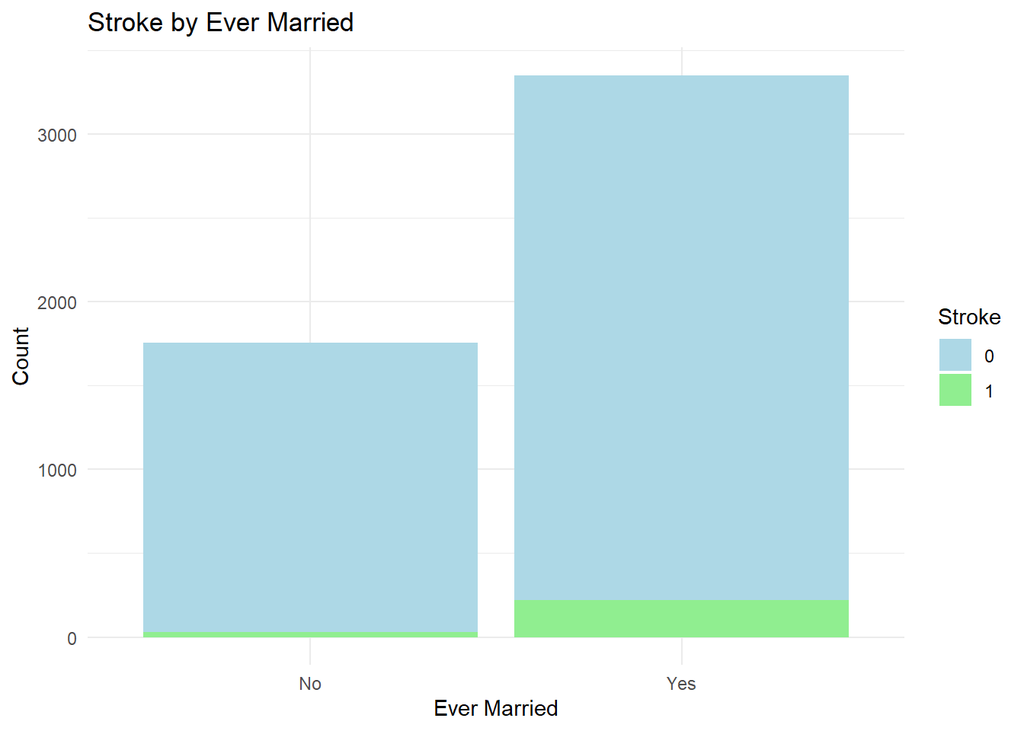

```r
pp7 <- ggplot(m_data, aes(x = ever_married_label, y = count, fill = factor(stroke))) +
  geom_bar(stat = "identity") +
  scale_fill_manual(values = c("lightblue", "lightgreen")) +
  labs(x = "Ever Married", y = "Count", fill = "Stroke") +
  ggtitle("Stroke by Ever Married") +
  theme_minimal()
pp7
```

There is a greater chance of stroke among people who have been married.

##Multivariate Analysis

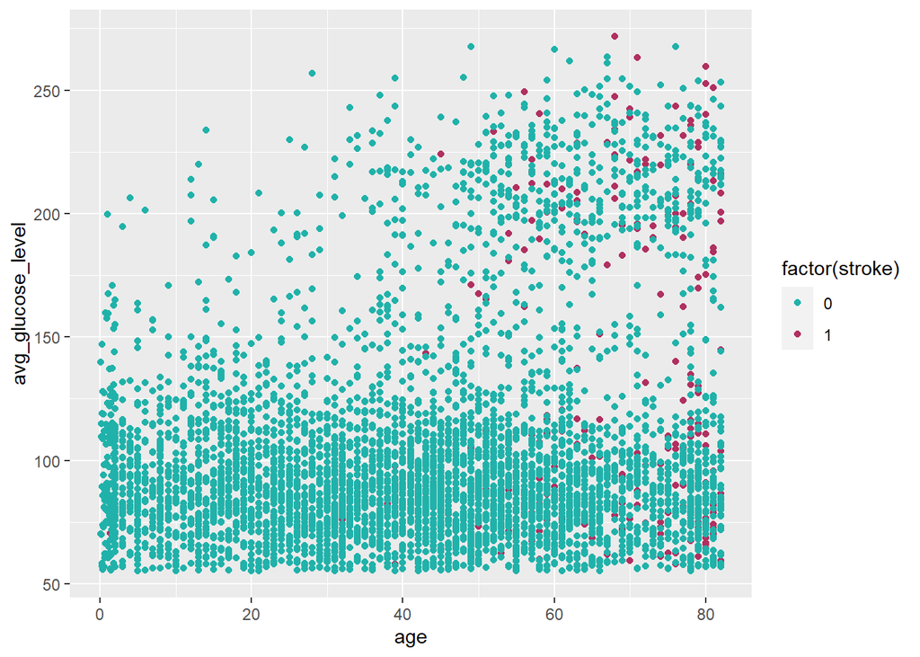

```r
ggplot(cleaned_data, aes(age, avg_glucose_level)) +
  geom_point(aes(color = factor(stroke))) +
  scale_color_manual(values = c("light sea green", "maroon"))
```

That plot shows that most people with high blood glucose are elderly people, and those people with higher blood glucose and older ages are more likely to suffer strokes in percentage.

###Associate between multiple variable

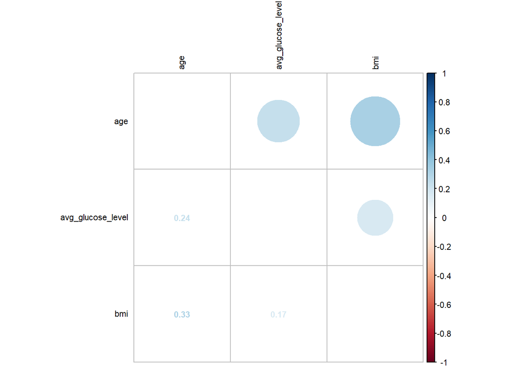

```r
df_num = cleaned_data
df_num <- select(cleaned_data,age,avg_glucose_level,bmi)
cor_num_var <- cor(df_num, use="pairwise.complete.obs")
corrplot.mixed(cor_num_var, tl.col="black", tl.pos = "lt"
               , tl.cex = 0.7,cl.cex = .7, number.cex=.7)
```

The continuous variables do not exhibit strong correlations, because the Pearson’s correlation is less than 0.4 for all of them.

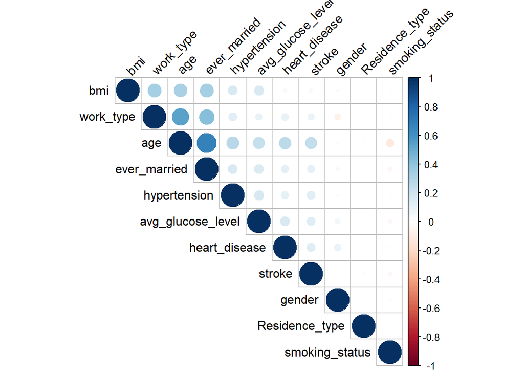

```r
df_cat = cleaned_data
df_cat$gender <- as.numeric(df_cat$gender)
df_cat$hypertension <- as.numeric(df_cat$hypertension)
df_cat$heart_disease <- as.numeric(df_cat$heart_disease)
df_cat$ever_married <- as.numeric(df_cat$ever_married)
df_cat$work_type <- as.numeric(df_cat$work_type)
df_cat$Residence_type <- as.numeric(df_cat$Residence_type)
df_cat$smoking_status <- as.numeric(df_cat$smoking_status)
df_cat$stroke <- as.numeric(df_cat$stroke)
res <- cor(df_cat)
corrplot(res, type = "upper", order = "hclust",
         tl.col = "black", tl.srt = 45)
```

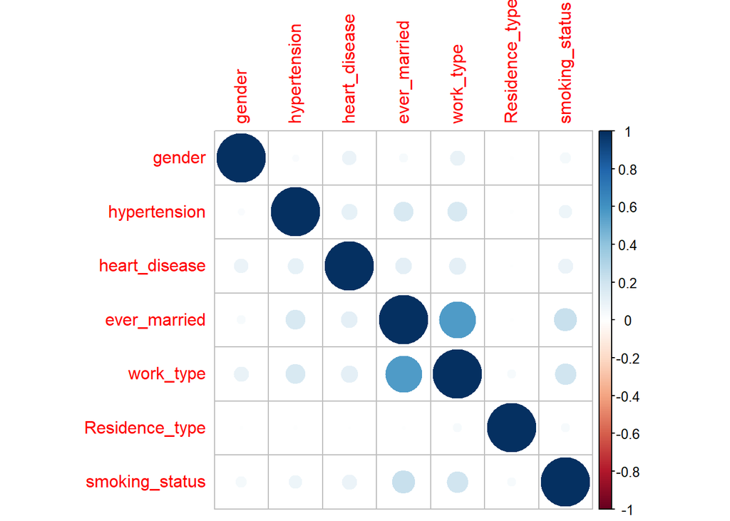

```r
df_cat = cleaned_data
df_cat <- select(cleaned_data,-age,-avg_glucose_level,-bmi,-stroke)
df_cat$gender <- as.numeric(df_cat$gender)
df_cat$hypertension <- as.numeric(df_cat$hypertension)
df_cat$heart_disease <- as.numeric(df_cat$heart_disease)
df_cat$ever_married <- as.numeric(df_cat$ever_married)
df_cat$work_type <- as.numeric(df_cat$work_type)
df_cat$Residence_type <- as.numeric(df_cat$Residence_type)
df_cat$smoking_status <- as.numeric(df_cat$smoking_status)

m <- DescTools::PairApply(df_cat, DescTools::CramerV)
corrplot::corrplot(m)
```

### Association between categorical variables

```r
library(vcd)
tbl1 <- table(cleaned_data$stroke, cleaned_data$gender)
tbl2 <- table(cleaned_data$stroke, cleaned_data$hypertension)
tbl3 <- table(cleaned_data$stroke, cleaned_data$heart_disease)
tbl4 <- table(cleaned_data$stroke, cleaned_data$ever_married)
tbl5 <- table(cleaned_data$stroke, cleaned_data$work_type)
tbl6 <- table(cleaned_data$stroke, cleaned_data$Residence_type)
tbl7 <- table(cleaned_data$stroke, cleaned_data$smoking_status)
assocstats(tbl1)
```

```
##                      X^2 df P(> X^2)
## Likelihood Ratio 0.41953  2  0.81078
## Pearson              NaN  2      NaN
##
## Phi-Coefficient   : NA
## Contingency Coeff.: NaN
## Cramer's V        : NaN
```

```r
assocstats(tbl2)
```

```
##                     X^2 df   P(> X^2)
## Likelihood Ratio 61.053  1 5.5511e-15
## Pearson          83.564  1 0.0000e+00
##
## Phi-Coefficient   : 0.128
## Contingency Coeff.: 0.127
## Cramer's V        : 0.128
```

```r
assocstats(tbl3)
```

```
##                     X^2 df   P(> X^2)
## Likelihood Ratio 60.251  1 8.3267e-15
## Pearson          92.980  1 0.0000e+00
##
## Phi-Coefficient   : 0.135
## Contingency Coeff.: 0.134
## Cramer's V        : 0.135
```

```r
assocstats(tbl4)
```

```
##                     X^2 df  P(> X^2)
## Likelihood Ratio 70.960  1 0.000e+00
## Pearson          59.922  1 9.881e-15
##
## Phi-Coefficient   : 0.108
## Contingency Coeff.: 0.108
## Cramer's V        : 0.108
```

```r
assocstats(tbl5)
```

```
##                     X^2 df   P(> X^2)
## Likelihood Ratio 69.761  4 2.5535e-14
## Pearson          49.159  4 5.4090e-10
##
## Phi-Coefficient   : NA
## Contingency Coeff.: 0.098
## Cramer's V        : 0.098
```

```r
assocstats(tbl6)
```

```
##                     X^2 df P(> X^2)
## Likelihood Ratio 1.2157  1  0.27021
## Pearson          1.2139  1  0.27055
##
## Phi-Coefficient   : 0.015
## Contingency Coeff.: 0.015
## Cramer's V        : 0.015
```

```r
assocstats(tbl7)
```

```
##                     X^2 df   P(> X^2)
## Likelihood Ratio 21.516  3 8.2256e-05
## Pearson             NaN  3        NaN
##
## Phi-Coefficient   : NA
## Contingency Coeff.: NaN
## Cramer's V        : NaN
```

Among the categorical variables, there is no strong association with the target variable. All categorical variables showed weak associations with the stroke variable.

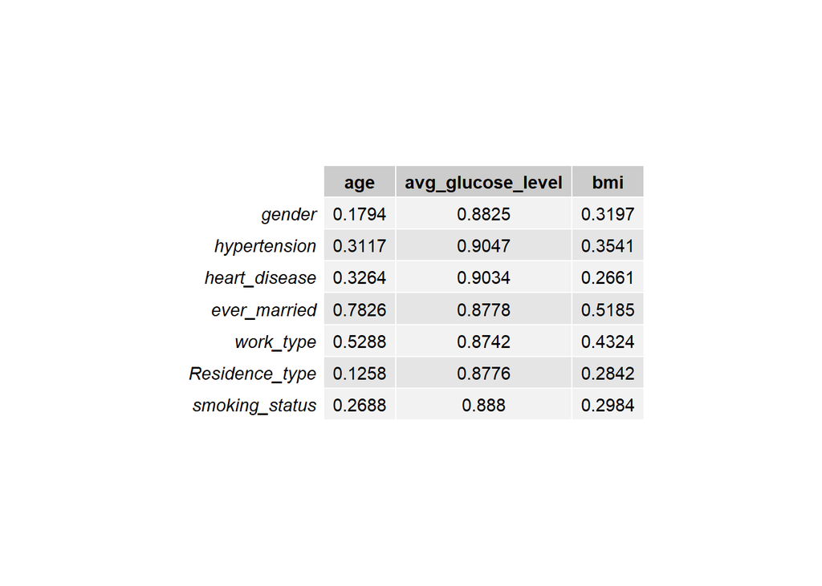

```r
df_num <- select(cleaned_data,age,avg_glucose_level,bmi)
a = matrix(nrow = 7,ncol = 3)
o=1
k=1
for(i in df_cat){
  for(j in df_num){
    a[o,k] =  cramerV(i,j)
    k = k+1
  }
  o = o+1
  k=1
}
a <- data.frame(a)
rownames(a) <- colnames(df_cat)
colnames(a) <- colnames(df_num)
ggtexttable(a)
```

1. Glucose level has a high correlation with other categorical features.
2. Age and ever_married have a relationship.

```r
spearman2(~stroke + gender + age + hypertension + heart_disease + ever_married + work_type + Residence_type + + avg_glucose_level + bmi + smoking_status, data = cleaned_data)
```

```
##
## Spearman rho^2    Response variable:stroke
##
##                    rho2      F df1  df2      P Adjusted rho2    n
## gender            0.000   0.42   1 5107 0.5164         0.000 5109
## age               0.062 339.10   1 5107 0.0000         0.062 5109
## hypertension      0.016  84.92   1 5107 0.0000         0.016 5109
## heart_disease     0.018  94.67   1 5107 0.0000         0.018 5109
## ever_married      0.012  60.61   1 5107 0.0000         0.012 5109
## work_type         0.010  12.40   4 5104 0.0000         0.009 5109
## Residence_type    0.000   1.21   1 5107 0.2706         0.000 5109
## avg_glucose_level 0.007  35.07   1 5107 0.0000         0.007 5109
## bmi               0.003  15.48   1 5107 0.0001         0.003 5109
## smoking_status    0.005   7.98   3 5105 0.0000         0.004 5109
```

This table presents the Spearman’s rank correlation coefficient squared (rho^2) for different predictor variables with the response variable “stroke” in a dataset.

1. Age: Age exhibits a moderate correlation (rho^2 = 0.062) with stroke, suggesting that there is a notable association between age and the occurrence of strokes.
2. Hypertension: There is a weak correlation (rho^2 = 0.016) between hypertension and stroke, indicating a slight relationship between the two variables.
3. Heart Disease: Similarly, heart disease shows a modest correlation (rho^2 = 0.018) with stroke, suggesting a moderate association between the presence of heart disease and the likelihood of experiencing a stroke.
4. Average Glucose Level: The average glucose level has a small correlation (rho^2 = 0.007) with stroke, indicating a weak relationship between glucose levels and the occurrence of strokes.
5. BMI: BMI exhibits a slight correlation (rho^2 = 0.003) with stroke, suggesting a weak association between BMI and the likelihood of experiencing a stroke.
6. Gender: Gender shows a negligible correlation (rho^2 = 0.000) with stroke, indicating that gender differences have little impact on the occurrence of strokes in the dataset.
7. Ever Married: The variable “ever_married” has a moderate correlation (rho^2 = 0.012) with stroke, suggesting a notable association between marriage status and the likelihood of experiencing a stroke.
8. Work Type: The work type variable shows a moderate correlation (rho^2 = 0.010) with stroke, indicating that the type of work individuals engage in may have some influence on the occurrence of strokes.
9. Residence Type: Residence type exhibits a negligible correlation (rho^2 = 0.000) with stroke, suggesting that the location of an individual’s residence has little impact on the occurrence of strokes.
10. Smoking Status: There is a weak correlation (rho^2 = 0.005) between smoking status and stroke, indicating a slight association between smoking habits and the likelihood of experiencing a stroke.

# Splitting Data

```r
set.seed(123)

n <- nrow(cleaned_data)
train <- sample(n, round(0.8 * n))
strokeTrain <- cleaned_data[train,]
strokeValidation <- cleaned_data[-train,]
```

### Dimension of training and testing data

```r
print("Dimension of training data: ")
```

```
## [1] "Dimension of training data: "
```

```r
dim(strokeTrain)
```

```
## [1] 4087   11
```

```r
print("Dimension of testing data: ")
```

```
## [1] "Dimension of testing data: "
```

```r
dim(strokeValidation)
```

```
## [1] 1022   11
```

# Random Forest model

### Fit the Random forest classifier with all variable

```r
RFModel <- randomForest(stroke ~ ., data = strokeTrain)
importance(RFModel, type = 2)
```

```
##                   MeanDecreaseGini
## gender                   10.418660
## age                      79.598442
## hypertension              9.311005
## heart_disease             8.013200
## ever_married              6.362815
## work_type                16.787830
## Residence_type           10.565744
## avg_glucose_level        97.266318
## bmi                      78.775840
## smoking_status           17.120627
```

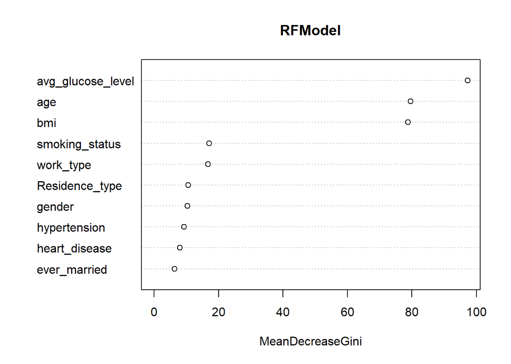

```r
varImpPlot(RFModel)
```

As we can see, the most important variable are avg_glucose_level, age and bmi.

### Model validation of random forest classifier

```r
predictionRF <- predict(RFModel, newdata = strokeValidation)
```

### Model performance of random forest classifier

```r
cm <- table(predictionRF, strokeValidation$stroke)
accuracy <- round(sum(diag(cm)) / sum(cm), 3)
sen1 <- Sensitivity(strokeValidation$stroke, predictionRF)
sprintf("Accuracy of Random forest model: %s", accuracy)
```

```
## [1] "Accuracy of Random forest model: 0.944"
```

```r
sprintf("Sensitifity of Random forest model: %s", sen1)
```

```
## [1] "Sensitifity of Random forest model: 0.998964803312629"
```

```r
cm
```

```
##
## predictionRF   0   1
##            0 965  56
##            1   1   0
```

### Conclusion of random forest model

Using all the variables, the random forest classifier model produces the following confusion matrix:

- True Positive (TP): The number of data correctly predicted as “having stroke” by the random forest model is 0.
- False Negative (FN): The number of data that should have been classified as “not have stroke” but was incorrectly predicted as “have stroke” by the random forest model was 1.
- False Positive (FP): The number of data that should be classified as “have stroke” but wrongly predicted as “not have stroke” by the random forest model is 56.
- True Negative (TN): The number of data that were correctly predicted as “not have stroke” by the random forest model was 965.

Thus we can see that the accuracy obtained by this model is 0.944 or 94% with a sesitifity level of 99%.

# Decision Tree

### Fit the Decision tree classifier with all variables

```r
DTModel <- rpart(stroke~., data= strokeTrain, cp= 0.001, method= "class")
DTModel$variable.importance
```

```
##               age avg_glucose_level               bmi         work_type
##         34.287882         15.733506          8.995658          4.599397
##      ever_married    smoking_status            gender     heart_disease
##          2.598070          2.488491          2.366200          1.841972
##    Residence_type
##          1.171199
```

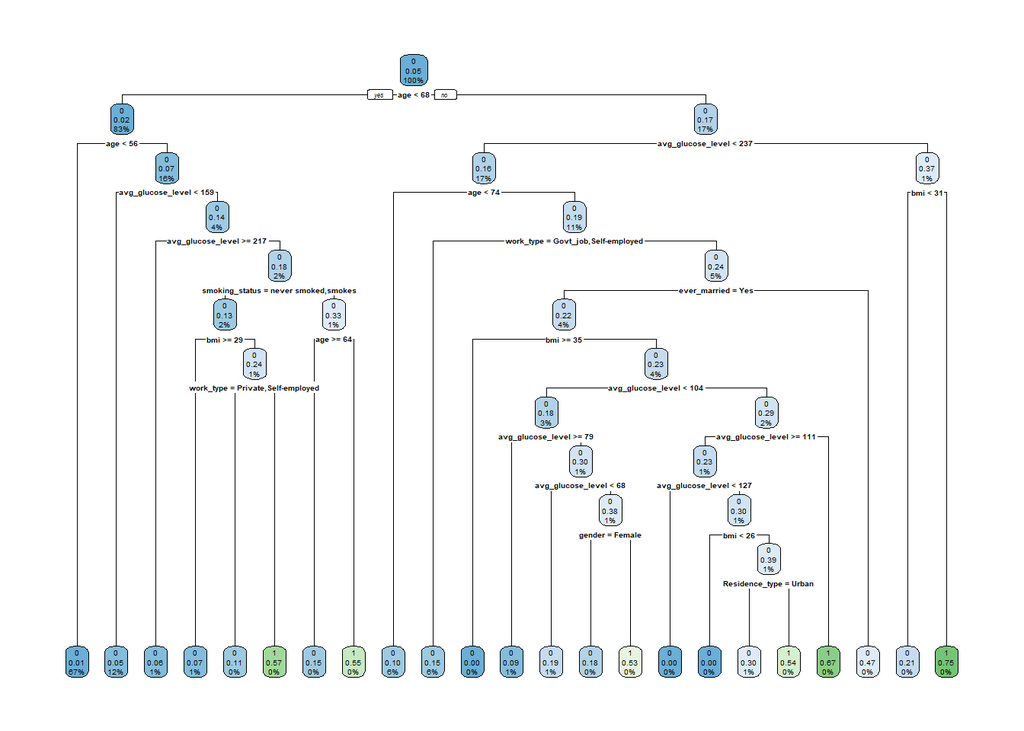

```r
rpart.plot(DTModel)
```

As we can see, the most important variable in for decision tree are age, avg_glucose_level, bmi. It’s same as random forest classifier important variable

### Model validation of decision tree

```r
DTPred <- predict(DTModel, newdata = strokeValidation, type = "class")
```

### Model performance of Decision tree models

```r
cm <- table(DTPred, strokeValidation$stroke)
accuracy <- round(sum(diag(cm)) / sum(cm), 3)
sensitifity <- Sensitivity(strokeValidation$stroke, DTPred)
sprintf("Accuracy of Decision Tree: %s", accuracy)
```

```
## [1] "Accuracy of Decision Tree: 0.932"
```

```r
sprintf("Sensitifity of Decision Tree: %s", sensitifity)
```

```
## [1] "Sensitifity of Decision Tree: 0.985507246376812"
```

```r
cm
```

```
##
## DTPred   0   1
##      0 952  55
##      1  14   1
```

### Conclusion of decision tree model

Using all the variables, the decision tree classifier model produces the following confusion matrix:

- True Positive (TP): The number of data correctly predicted as “having stroke” by the decision tree model is 1.
- False Negative (FN): The number of data that should have been classified as “not have stroke” but was incorrectly predicted as “have stroke” by the decision tree model was 14.
- False Positive (FP): The number of data that should be classified as “have stroke” but wrongly predicted as “not have stroke” by the decision tree model is 55.
- True Negative (TN): The number of data that were correctly predicted as “not have stroke” by the decision tree model was 952.

# Logistic regression

### Fit the Logistic regression classifier with all variables

```r
LRModel <- glm(stroke ~., family="binomial", data = strokeTrain)
summary(LRModel)
```

```
##
## Call:
## glm(formula = stroke ~ ., family = "binomial", data = strokeTrain)
##
## Deviance Residuals:
##     Min       1Q   Median       3Q      Max
## -1.1531  -0.3083  -0.1578  -0.0879   3.5133
##
## Coefficients:
##                              Estimate Std. Error z value Pr(>|z|)
## (Intercept)                -6.463e+00  7.995e-01  -8.084 6.27e-16 ***
## genderMale                 -5.868e-02  1.613e-01  -0.364  0.71604
## age                         7.491e-02  6.704e-03  11.174  < 2e-16 ***
## hypertension1               5.526e-01  1.812e-01   3.050  0.00229 **
## heart_disease1              2.375e-01  2.163e-01   1.098  0.27240
## ever_marriedYes            -1.195e-01  2.551e-01  -0.468  0.63953
## work_typeGovt_job          -1.450e+00  8.730e-01  -1.661  0.09675 .
## work_typeNever_worked      -1.060e+01  3.326e+02  -0.032  0.97456
## work_typePrivate           -1.206e+00  8.491e-01  -1.420  0.15552
## work_typeSelf-employed     -1.643e+00  8.767e-01  -1.874  0.06099 .
## Residence_typeUrban         3.588e-02  1.568e-01   0.229  0.81898
## avg_glucose_level           4.346e-03  1.344e-03   3.233  0.00123 **
## bmi                         1.742e-04  1.299e-02   0.013  0.98930
## smoking_statusnever smoked -1.518e-01  1.844e-01  -0.823  0.41041
## smoking_statussmokes        1.222e-01  2.455e-01   0.498  0.61860
## ---
## Signif. codes:  0 '***' 0.001 '**' 0.01 '*' 0.05 '.' 0.1 ' ' 1
##
## (Dispersion parameter for binomial family taken to be 1)
##
##     Null deviance: 1555.1  on 4086  degrees of freedom
## Residual deviance: 1233.2  on 4072  degrees of freedom
## AIC: 1263.2
##
## Number of Fisher Scoring iterations: 14
```

### Model validation of Logistic regression

```r
lrPred <- predict(LRModel, newdata = strokeValidation, type = "response")
```

### Model performance of Logistic regression models

```r
threshold <- table(strokeValidation$stroke, lrPred > 0.5)
accuracy <- round(sum(diag(threshold)) / sum(threshold), 3)
sensitifity <- threshold[4]/(threshold[4]+threshold[2])
threshold
```

```
##
##     FALSE TRUE
##   0   966    0
##   1    55    1
```

```r
sprintf("Accuracy of Logistic Regression: %s", accuracy)
```

```
## [1] "Accuracy of Logistic Regression: 0.946"
```

```r
sprintf("Sensitifity of Logistic Regression: %s", accuracy)
```

```
## [1] "Sensitifity of Logistic Regression: 0.946"
```

### Conclusion of logistic regression model

# Final Conclusion

After experimenting with three models, namely random forest, decision tree and logistic regression with each model using all available variables, the reason we used all the variables in the dataset is because it goes back to our objective where we want to predict silent strokes that can occur regardless of gender, environment, status, lifestyle and medical history that can cause silent strokes. Therefore, we compared several different models for this case.

Based on the performance of the three models, the random forest model gave better results than the decision tree or logistic regression, and the decision tree gave the lowest accuracy. Although in terms of accuracy, the logistic regression model gives a slightly higher accuracy of 0.946 or 0.002 more than the random forest model, the random forest model can handle non-linear cases, insignificant variables, and redundant features better. Therefore, we chose random forest as the model for classification in this case.

For the final model, we used a random forest model using all variables because it goes back to the objective, which is to predict silent strokes that can occur regardless of gender, lifestyle, status, environment, and medical history that can cause silent strokes.